## EDA - Indian startup analysis

# AIM :

Data cleaning and handling missing values

1. Are there any outliers in the "No. of Investors" column? How might these outliers impact the analysis of investor interest in different sectors?
2. Are there any missing values in critical columns like 'Company', 'City', 'Starting Year', or 'Founders'? How should these be handled?
3. Are there any outliers in the "Funding Amount in $" column? How can these outliers be identified and potentially handled?
4. Are there any opportunities to aggregate the data for better insights, such as summing funding amounts by city or industry?
5. Are there any duplicate entries in the dataset? If so, how should they be handled?

Visualisation

1. Are there any trends in the funding amount received by startups based on the "Starting Year"?
2. Create a line chart showing the total funding amount raised by startups each year. Highlight any significant spikes or dips in funding activity.
3. Generate a bar chart showing the number of startups in each industry category. Label the top 5 industries with the highest number of startups.

```python
import pandas as pd
import matplotlib.pyplot as plt
import seaborn as sns
```

```python
# Loading thr dataset

data = pd.read_csv("C:/Users/91771/Downloads/Indian Startups - Startups1.csv")
```

```python
#Checking basic information about dataset

data.head()
```

|  | Company | City | Starting Year | Founders | Industries | Description | No. of Employees | Funding Amount in $ | Funding Round | No. of Investors |
| --- | --- | --- | --- | --- | --- | --- | --- | --- | --- | --- |
| 0 | Urban Company | Gurgaon | 2014 | Abhiraj Singh Bhal, Raghav Chandra, Varun Khaitan | Apps, Home Services, Marketplace, Service Indu... | Urban is a marketplace for independent contrac... | 1001-5000 | 445920356 | 12 | 16 |
| 1 | Classplus | Noida | 2018 | Bhaswat Agarwal, Bikash Dash, Mukul Rustagi, N... | B2B, E-Learning, EdTech, Education, Mobile App... | Classplus is a mobile-first SaaS platform that... | 101-250 | 89506451 | 10 | 20 |
| 2 | Paytm | Noida | 2010 | Akshay Khanna, Vijay Shekhar Sharma | E-Commerce, Finance, Financial Services, Inter... | Paytm is a payment gateway that allows users a... | 501-1000 | 32448851 | 4 | 4 |
| 3 | Apna | Mumbai | 2019 | Nirmit Parikh | Employment, Human Resources, Recruiting, Staff... | Apna is a professional networking and job-sear... | 101-250 | 93450000 | 4 | 6 |
| 4 | Razorpay | Bengaluru | 2014 | Harshil Mathur, Shashank Kumar | Financial Services, FinTech, Payments, Software | Razorpay is a payment acceptance, processing, ... | 1001-5000 | 366600000 | 7 | 29 |

```python
data.info()

#Checking for missing values in dataset

data.isnull().sum()
```

```
<class 'pandas.core.frame.DataFrame'>
RangeIndex: 300 entries, 0 to 299
Data columns (total 10 columns):
 #   Column               Non-Null Count  Dtype
---  ------               --------------  -----
 0   Company              300 non-null    object
 1   City                 300 non-null    object
 2   Starting Year        300 non-null    int64
 3   Founders             300 non-null    object
 4   Industries           300 non-null    object
 5   Description          300 non-null    object
 6   No. of Employees     300 non-null    object
 7   Funding Amount in $  300 non-null    int64
 8   Funding Round        300 non-null    int64
 9   No. of Investors     300 non-null    int64
dtypes: int64(4), object(6)
memory usage: 23.6+ KB
```

```
Company                0
City                   0
Starting Year          0
Founders               0
Industries             0
Description            0
No. of Employees       0
Funding Amount in $    0
Funding Round          0
No. of Investors       0
dtype: int64
```

As there are no missing values and no need converting dtypes of any column , all are appropriate Moving forward

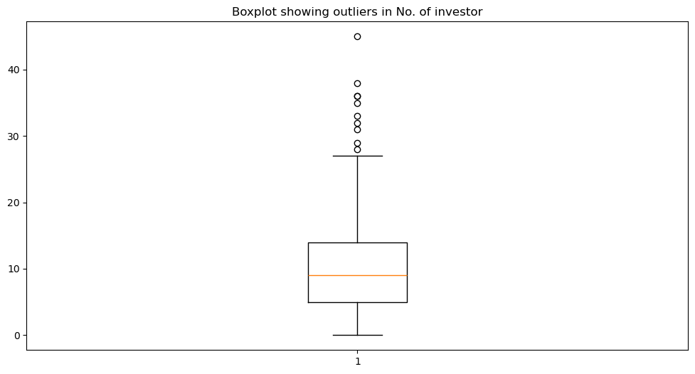

```python
#To check the outlers in "No_of_investor" column . we can visual a boxplot to get overview of outliers in it

plt.figure(figsize = (12,6))
plt.boxplot(data['No. of Investors'])
plt.title('Boxplot showing outliers in No. of investor')
plt.show()
```

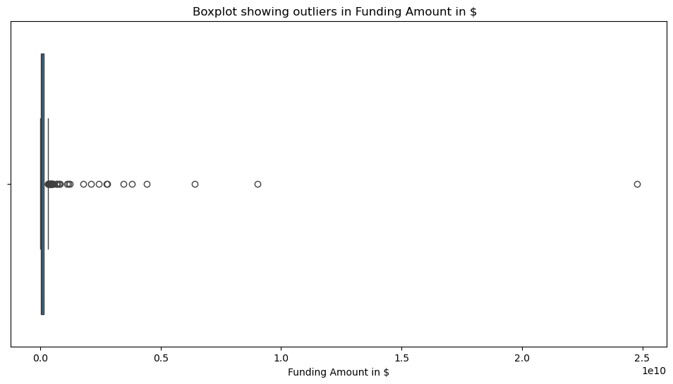

```python
#Similarly for "Funding Amount in $ " column

plt.figure(figsize = (12,6))
sns.boxplot(data = data ,x=data['Funding Amount in $'])
plt.title('Boxplot showing outliers in Funding Amount in $  ')
plt.show()
```